DS 6030 | Fall 2024 | University of Virginia

# Homework #9: Feature Importance

Author

**SOLUTIONS**

Published

Fall 2024

**Warning**

These solutions are only for the private use of the students of DS 6030 Fall 2024. Sharing of the solutions, posting on the internet, selling to a company, or possession by anyone outside of the class constitutes a violation of the honor policy.

# Required R packages and Directories

```r
dir_data = 'https://mdporter.github.io/teaching/data/' # data directory
library(tidyverse) # functions for data manipulation
library(tidymodels)
library(ranger)
```

# Problem 1: Permutation Feature Importance

Vanderbilt Biostats has collected data on Titanic survivors (https://hbiostat.org/data/). I have done some simple processing and split into a training and test sets.

- titanic_train.csv
- titanic_test.csv

We are going to use this data to investigate feature importance. Use `Class`, `Sex`, `Age`, `Fare`, `sibsp` (number of siblings or spouse on board), `parch` (number of parents or children on board), and `Joined` (city where passenger boarded) for the predictor variables (features) and `Survived` as the outcome variable.

## a. Load the titanic traning and testing data

**Solution**

```r
titanic_train = read_csv(file.path(dir_data, "titanic_train.csv"))
titanic_test = read_csv(file.path(dir_data, "titanic_test.csv"))
```

## b. Method 1: Built-in importance scores

Fit a tree ensemble model (e.g., Random Forest, boosted tree) on the training data. You are free to use any method to select the tuning parameters.

Report the built-in feature importance scores and produce a barplot with feature on the x-axis and importance on the y-axis.

**Solution**

I’m going to go with a random forest model using the `ranger` package implementation. I’ll set the number of trees to something large (e.g., 2000), allow deep trees, and only tune `mtry`.

I’ll use `gini` to split the nodes and specify the built-in `impurity` measure for feature importance.

For tuning `mtry`, I’ll use the out-of-bag (oob) scores from `ranger` instead of cross-validation. Recall, that a `ranger` object returns the oob brier score in the `prediction.error` element.

**Ranger Package**

Convert `Survived` into a factor (to ensure the model knows its a classification problem), and use median imputation for the missing `Age`’s and `Fare`’s.

```r
library(tidyverse)

train = titanic_train %>%
  mutate(
    Survived = factor(Survived, c(0,1)),             # convert outcome to factor
    Age = coalesce(Age, median(Age, na.rm=TRUE)),    # mean imputation of Age
    Fare = coalesce(Fare, median(Fare, na.rm=TRUE))  # mean imputation of Fare
    ) %>%
  as_tibble()
#: note that to avoid data leakage, I'm careful to use the *training data* median for imputation.
test = titanic_test %>%
  mutate(
    Survived = factor(Survived, c(0,1)),          # convert outcome to factor
    Age = coalesce(Age, median(titanic_train$Age, na.rm=TRUE)), # mean imputation of Age
    Fare = coalesce(Fare, median(titanic_train$Fare, na.rm=TRUE)) # mean imputation of Age
  ) %>%
  as_tibble()
```

I’m going with the `ranger` version of Random Forest. The `ranger` package can run a bit faster than `randomForest` and allows some more advanced settings. I’ll specify that I want to return probability estimates and use the gini-base gain score for importance. Because I’m going to tune over `mtry`, I’ll make function that will fit `ranger` for a input `mtry`:

```r
library(ranger)
fit_ranger <- function(mtry, data_train, seed = 1033){
  ranger(Survived ~ Class + Sex + Age + sibsp + parch + Fare + Joined,
          data = data_train,
           # tuning parameters
           mtry = mtry,
           num.trees = 2000,
           min.node.size = 2,
           splitrule = "gini",
           # settings
           probability = TRUE,
           importance = "impurity", # use impurity (Gini-based gain score)
           seed = seed
           )
}
```

```r
#: specify grid of mtry values
mtry_vals = set_names(seq(1, 7, by = 1))

#: fit rf with mtry and extract ranger object
oob = purrr::map_dbl(mtry_vals,
    \(m) fit_ranger(mtry = m, data_train = train)$prediction.error
    ) %>%
  enframe(name = "mtry", value = "oob_loss") %>%
  arrange(oob_loss)

oob
```

```
# A tibble: 7 × 2
  mtry  oob_loss
  <chr>    <dbl>
1 2        0.136
2 3        0.139
3 4        0.144
4 5        0.147
5 6        0.150
6 1        0.151
# ℹ 1 more row
```

```r
RF = fit_ranger(mtry = as.numeric(oob$mtry[1]), train)
```

The fitted `ranger` object has a `variable.importance` element. I’ll standardize so the importance scores sum to one (not necessary to do so).

```r
importance_builtin = {RF$variable.importance / sum(RF$variable.importance)} %>%
  enframe(name = "feature", value = "importance") %>%
  arrange(-importance)
importance_builtin
```

```
# A tibble: 7 × 2
  feature importance
  <chr>        <dbl>
1 Sex         0.356
2 Fare        0.217
3 Age         0.182
4 Class       0.104
5 sibsp       0.0493
6 parch       0.0459
# ℹ 1 more row
```

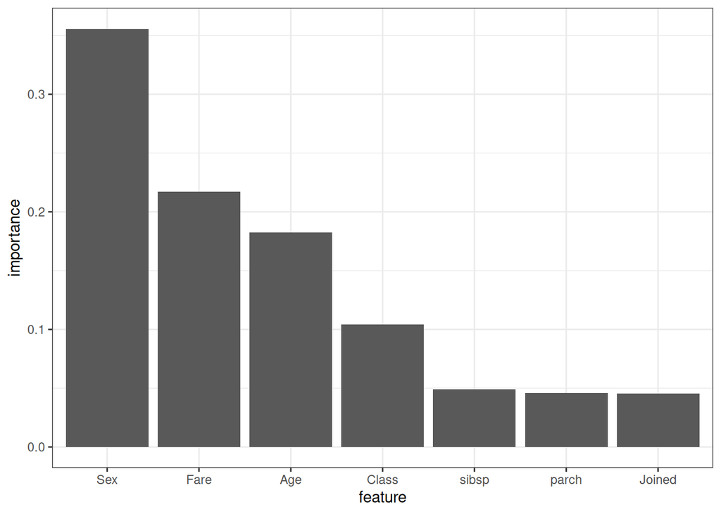

```r
ggplot(importance_builtin, aes(reorder(feature, -importance), importance)) +
  geom_col() +
  labs(x = "feature")
```

**Tidymodels**

First, make workflow object. Notice that `Survived` is converted to a factor so `rand_forest` doesn’t complain. We also need to deal with missing values; will do median imputation.

```r
library(tidymodels)

rf_rec =
  recipe(
    Survived ~ Class + Sex + Age + Fare + sibsp + parch + Joined,
    data = titanic_train
  ) %>%
  step_bin2factor(Survived, skip = TRUE) %>%
  # set skip = TRUE to ignore transformation on test data
  step_impute_median(all_numeric_predictors())


rf_spec =
  rand_forest(mode = "classification", engine = "ranger") %>%
  set_args(
    # rand_forest args
    mtry = tune(),
    trees = 2000,
    min_n = 2,
    # ranger specific args
    splitrule = "gini",
    importance = "impurity",
    seed = 1033
  )

rf_wf = workflow(preprocessor = rf_rec, spec = rf_spec)
```

To save some computing time, I’ll use out-of-bag scores from `ranger` instead of cross-validation. Recall, that a `ranger` object returns the oob brier score in the `prediction.error` element. So here I’ll loop of all possible `mtry` values, extract the fitted `ranger` object using `extract_fit_engine()` and then retrieve the oob loss.

```r
#: specify grid of mtry values
mtry_vals = seq(1, 7, by = 1)

#: fit rf with mtry and extract ranger object
fit_list = map(mtry_vals,
    \(m) rf_wf %>%
      finalize_workflow(tibble(mtry = m)) %>%
      fit(titanic_train) %>%
      extract_fit_engine()
    )

#: tune mtry
rf_tune =
  map(fit_list, \(x) tibble(mtry = x$mtry, oob_loss = x$prediction.error)) %>%
  bind_rows() %>%
  arrange(oob_loss)

rf_tune
```

```
# A tibble: 7 × 2
   mtry oob_loss
  <dbl>    <dbl>
1     2    0.136
2     3    0.139
3     4    0.143
4     5    0.147
5     6    0.150
6     1    0.151
# ℹ 1 more row
```

```r
RF_tidy = rf_wf %>%
  finalize_workflow(tibble(mtry = rf_tune$mtry[1])) %>%
  fit(titanic_train)
```

To get variable importance, we could extract the `ranger` object with `extract_fit_engine()` as above, but I’ll stick with the `tidymodels` framework and use the `vip` package. I’ll standardize so the importance scores sum to one (not necessary to do so).

```r
importance_builtin_tidy =
  RF_tidy %>%
  vip::vi() %>% # This retrieves the importance element of ranger object
  mutate(Importance = Importance / sum(Importance))

importance_builtin_tidy
```

```
# A tibble: 7 × 2
  Variable Importance
  <chr>         <dbl>
1 Sex          0.356
2 Fare         0.214
3 Age          0.183
4 Class        0.106
5 sibsp        0.0496
6 parch        0.0462
# ℹ 1 more row
```

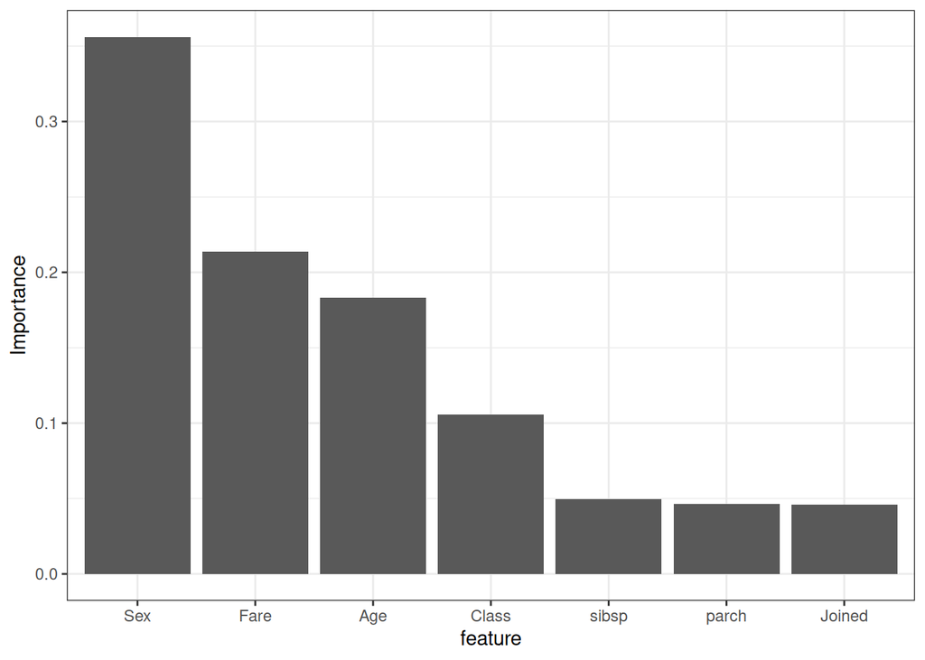

```r
ggplot(importance_builtin_tidy, aes(reorder(Variable, -Importance), Importance)) +
  geom_col() +
  labs(x = "feature")
```

Looks like `Sex` and `Fare` are the most important predictive features.

## c. Performance

Report the performance of the model fit from (a.) on the test data. Use the log-loss (where $M$ is the size of the test data):
$$\text{log-loss}(\hat{p}) = - \frac{1}{M} \sum_{i=1}^m [y_i \log \, \hat{p}_i + (1 - y_i) \log \, (1 - \hat{p}_i)]$$

**Solution**

**Manual Function**

Write a function to calculate the log-loss (cross-entropy).

```r
log_loss <- function(y, p_hat){
  eps = 1E-10
  p_hat = pmax(pmin(p_hat, 1-eps),eps)
  -mean(ifelse(y == 1, log(p_hat), log(1-p_hat)))
}
```

Calculate the test loss.

```r
(loss_base =
  log_loss(
    y = titanic_test$Survived,
    p_hat = predict(RF, test)$predictions[,"1"]
  )
)
```

```
[1] 0.412
```

**yardstick package**

Using the `yardstick::mn_log_loss()` function. `yardstick` is part of `tidymodels`.

```r
library(yardstick)
test %>%
  mutate(p_hat = predict(RF, .)$predictions[,"1"]) %>%
  mn_log_loss(truth = Survived, p_hat, event_level = "second")
```

```
# A tibble: 1 × 3
  .metric     .estimator .estimate
  <chr>       <chr>          <dbl>
1 mn_log_loss binary         0.412
```

## d. Method 2: Permute *after* fitting

Use the fitted model from question (a.) to perform permutation feature importance. Shuffle/permute each variable individually on the *test set* before making predictions. Record the loss. Repeat $M=10$ times and produce a boxplot of the change in loss (change from reported loss from part b.).

**Solution**

First thing I’ll do is make a function to carryout the permutation feature importance. Notice that this function accepts the model as an input.

```r
perm_feat_imp_2 <- function(model, data, var, M=1, seed=NULL){
  if(!is.null(seed)) set.seed(seed)
  loss = numeric(M)
  for(i in 1:M){
    data[[var]] = sample(data[[var]])
    loss[i] = log_loss(y = data$Survived, p_hat = predict(model, data)$predictions[,"1"])
  }
  tibble(loss, iter = 1:M, var)
}
```

Check that it works:

```r
perm_feat_imp_2(model = RF, data = test, var = "Class", M = 2)
```

```
# A tibble: 2 × 3
   loss  iter var
  <dbl> <int> <chr>
1 0.538     1 Class
2 0.519     2 Class
```

And loop over all variables (using `purr::map()` to implicitly implement the loop)

```r
vars = importance_builtin$feature  # vector of all variables
M = 10                             # number of replications
importance_2 = map_df(vars, \(j) perm_feat_imp_2(model = RF, data = test, var = j, M = M, seed = 2023))
```

Boxplot of change in loss

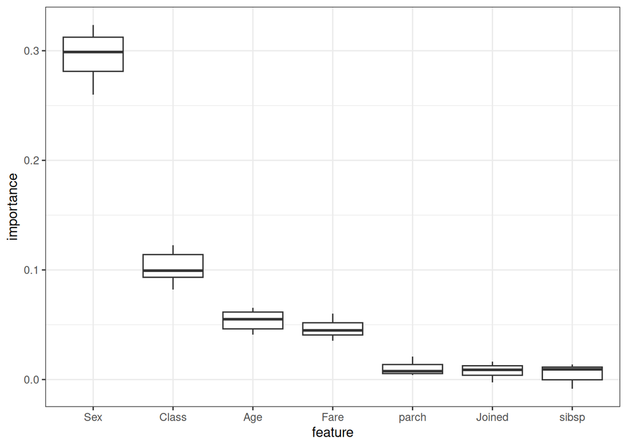

```r
importance_2 %>%
  mutate(importance = loss - loss_base) %>%
  ggplot(aes(reorder(var, -importance), importance)) +
  geom_boxplot() +
  labs(x = "feature")
```

This indicates that `Sex` is the most important (by far) followed by `Class`, `Age`, and `Fare`. The Port of Embarkation and number of family members on board doesn’t appear to be as important to this Random Forest.

## e. Method 3: Permute *before* fitting

For this approach, shuffle/permute the *training data* and re-fit the ensemble model. Evaluate the predictions on the (unaltered) test data. Repeat $M=10$ times (for each predictor variable) and produce a boxplot of the change in loss.

**Solution**

First thing I’ll do is make a function to carryout the permutation feature importance.

```r
#: function to tune and fit a random forest
tune_ranger <- function(data, ...){

  #: specify grid of mtry values
  mtry_vals = set_names(seq(1, 7, by = 1))

  #: fit rf with mtry and extract ranger object
  oob = purrr::map_dbl(mtry_vals,
      \(m) fit_ranger(mtry = m, data_train = data, ...)$prediction.error
      ) %>%
    enframe(name = "mtry", value = "oob_loss") %>%
    mutate(mtry = as.numeric(mtry)) %>%
    arrange(oob_loss)

  opt_tune = oob %>% slice_min(oob_loss, with_ties = FALSE)

  RF = fit_ranger(mtry = opt_tune$mtry, data_train = data)
  return(RF)
}

#: function for permutation feature importance
perm_feat_imp_3 <- function(fit, data_train, data_test, var, M=1, seed=NULL){
  if(!is.null(seed)) set.seed(seed)
  loss = numeric(M)
  for(i in 1:M){
    data_train[[var]] = sample(data_train[[var]])
    RF = fit(data_train)
    loss[i] = log_loss(test$Survived,
                       p_hat = predict(RF, data_test)$predictions[,"1"])
  }

  tibble(loss, iter = 1:M, var)
}
```

Check that it works:

```r
perm_feat_imp_3(tune_ranger, data_train = train, data_test = test, var = "Class", M = 2)
```

```
# A tibble: 2 × 3
   loss  iter var
  <dbl> <int> <chr>
1 0.435     1 Class
2 0.430     2 Class
```

And loop over all variables (using `purr::map()` to implicitly implement the loop)

```r
vars = importance_builtin$feature  # vector of all variables
M = 10                             # number of replications
importance_3 = map_df(vars, \(j) perm_feat_imp_3(tune_ranger, data_train = train, data_test = test, var = j, M = M, seed = 2023))
```

Boxplot of change in loss

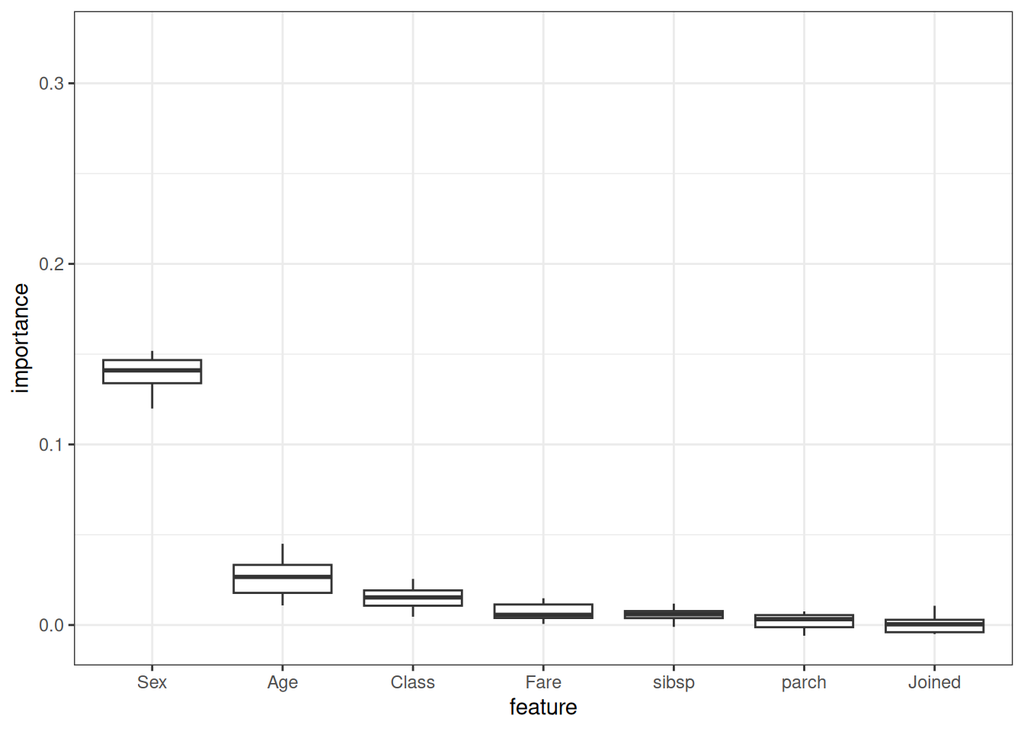

```r
importance_3 %>%
  mutate(importance = loss - loss_base) %>%
  ggplot(aes(reorder(var, -importance), importance)) +
  geom_boxplot() +
  scale_y_continuous(limits=c(NA, max(importance_2$loss - loss_base))) +
  labs(x = "feature")
```

Notice that the importance scores (i.e., changes in loss) are a bit smaller for Method 3 than Method 2. This indicates that the Random Forest is able to use associated (e.g., correlated) predictors to make-up for the loss of a feature.

## f. Understanding

Describe the benefits of each of the three approaches to measure feature importance.

**Solution**

- Method 1: the built-in gain-based approach is quick and easy. This approach gives a sense of how important the feature is to the *fitted* model.
- Method 2: permuting after model fitting is the quicker of the permutation approaches as it only requires making predictions from a fitted model. This also gives an indication of how influential a feature is to the fitted model.
- Method 3: permuting the training data before fitting leads to importance scores that are reflective of how valuable the feature is to collect. Feature with low importance scores on this metric are candidates for being dropped (feature selection).

Keep in mind that a poor model (e.g., over or under fit) can mislead feature importance. If a model severely overfits, the method 3 that uses a permuted value can actually provide a regularization effect leading to *better* performance on the test data.

# Problem 2: Effects of correlated predictors

This problem will illustrate what happens to the importance scores when there are highly associated predictors.

## a. Create an almost duplicate feature

Create a new feature `Sex2` that is 95% the same as `Sex`. Do this by selecting 5% of training ($n=50$) and testing ($n=15$) data and flip the `Sex` value.

**Solution**

```r
set.seed(991)
n_flip = 50
train2 = train %>%
  mutate(
    Sex_flip = ifelse(Sex == "female", "male", "female"),
    flip = c(rep(TRUE, n_flip), rep(FALSE, n() - n_flip) ) %>% sample(),
    Sex2 = ifelse(flip, Sex_flip, Sex)
  )
```

```r
set.seed(992)
n_flip = 15
test2 = test %>%
  mutate(
    Sex_flip = ifelse(Sex == "female", "male", "female"),
    flip = c(rep(TRUE, n_flip), rep(FALSE, n() - n_flip) ) %>% sample(),
    Sex2 = ifelse(flip, Sex_flip, Sex)
  )
```

## b. Method 1: Built-in importance

Fit the same model as in Problem 1a, but use the new data that includes `Sex2` (i.e., use both `Sex` and `Sex2` in the model). Calculate the built-in feature importance score and produce a barplot.

**Solution**

```r
library(ranger)
fit_ranger2 <- function(mtry, data_train, seed = 1033){
  ranger(Survived ~ Class + Sex + Age + sibsp + parch + Fare + Joined + Sex2,
          data = data_train,
           # tuning parameters
           mtry = mtry,
           num.trees = 2000,
           min.node.size = 2,
           splitrule = "gini",
           # settings
           probability = TRUE,
           importance = "impurity", # use impurity (Gini-based gain score)
           seed = seed
           )
}

tune_ranger2 <- function(data, ...){

  #: specify grid of mtry values
  mtry_vals = set_names(seq(1, 7, by = 1))

  #: fit rf with mtry and extract ranger object
  oob = purrr::map_dbl(mtry_vals,
      \(m) fit_ranger2(mtry = m, data_train = data, ...)$prediction.error
      ) %>%
    enframe(name = "mtry", value = "oob_loss") %>%
    mutate(mtry = as.numeric(mtry)) %>%
    arrange(oob_loss)

  opt_tune = oob %>% slice_min(oob_loss, with_ties = FALSE)

  RF = fit_ranger2(mtry = opt_tune$mtry, data_train = data)
  return(RF)
}

RF2 = tune_ranger2(train2)
```

The fitted `ranger` object has a `variable.importance` element. I’ll standardize so the importance scores sum to one (not necessary to do so).

```r
importance_builtin = {RF2$variable.importance / sum(RF2$variable.importance)} %>%
  enframe(name = "feature", value = "importance")
```

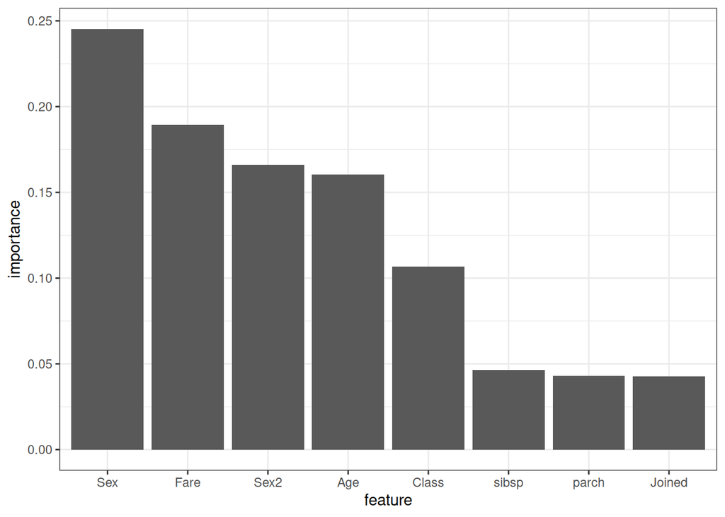

```r
ggplot(importance_builtin, aes(reorder(feature, -importance), importance)) +
  geom_col() +
  labs(x = "feature")
```

Notice that `Sex` is not as important as it was originally because `Sex2` has taken some if it’s importance. While the random forest still prefers the original `Sex`, it sometimes chooses to split on `Sex2`. This isn’t surprising because the two variables are so similar.

## c. Method 2: Permute *after* fitting

Redo Method 2 (problem 1c) on the new data/model and produce a boxplot of importance scores. The importance score is defined as the difference in loss.

**Solution**

```r
vars = importance_builtin$feature  # vector of all variables
M = 10                             # number of replications
importance_2 = map_df(vars, \(j) perm_feat_imp_2(model = RF2, data = test2, var = j, M = M, seed = 2023))
```

Boxplot of change in loss

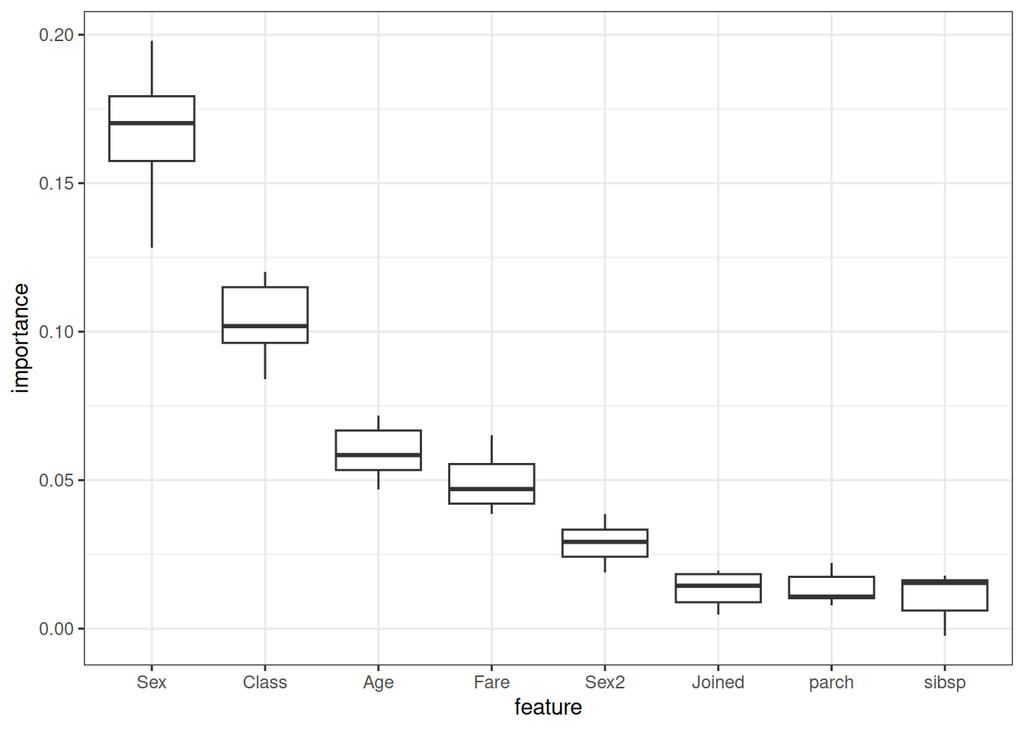

```r
importance_2 %>%
  mutate(importance = loss - loss_base) %>%
  ggplot(aes(reorder(var, -importance), importance)) +
  geom_boxplot() +
  labs(x = "feature")
```

This maintains that `Sex` is the most important predictor, but again it is less important given the substitute `Sex2`.

## d. Method 3: Permute *before* fitting

Redo Method 3 (problem 1d) on the new data and produce a boxplot of importance scores. The importance score is defined as the difference in loss.

**Solution**

```r
vars = importance_builtin$feature  # vector of all variables
M = 10                             # number of replications
importance_3 = map_df(vars, \(j) perm_feat_imp_3(tune_ranger2, data_train = train2, data_test = test2, var = j, M = M, seed = 2023))
```

Boxplot of change in loss

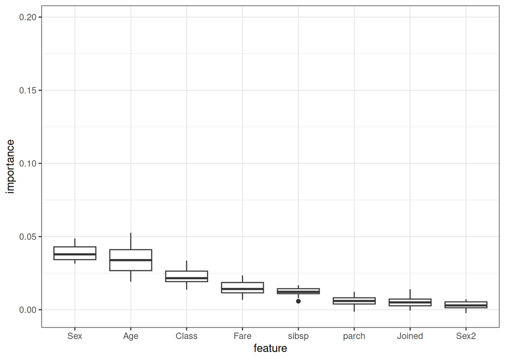

```r
importance_3 %>%
  mutate(importance = loss - loss_base) %>%
  ggplot(aes(reorder(var, -importance), importance)) +
  geom_boxplot() +
  scale_y_continuous(limits=c(NA, max(importance_2$loss - loss_base))) +
  labs(x = "feature")
```

Here’s where the big change come in. Notice that the importance of `Sex` is substantially decreased. This is because `Sex` can be replaced by `Sex2` and vice-versa because they are so similar. If we weren’t aware that the two were so associated, we would mistakenly think that `Sex` isn’t too important. However, we see that in this approach the unnecessary `Sex2` is least important and we could (rightly) drop it and still make good predictions.

## e. Understanding

Describe how the addition of the almost duplicated predictor impacted the feature importance results.

**Solution**

The inclusion of `Sex2` reduced the importance of the real feature, `Sex`, in all approaches. This indicates that all these approaches to feature importance are sensitive to how similar the feature is to other predictor variables.

Method 3 showed the strongest effect of reducing the importance of `Sex`. It could be good to compare the results of Method 3 to one of the others. A substantial importance drop under Method 3 indicates there are other features that could replace it.